# Session 1 - R und RStudio

## Vorstellung

### Philipp

- BA Staatswissenschaften, Universität Erfurt
- MSc SEDA, Universität Konstanz

### Jan

- BA Politik- und Verwaltungswissenschaften, Universität Konstanz
- MSc SEDA, Universität Konstanz

## Syllabus

## Session 1: R and RStudio

[figure not shown]

## Session 2: Daten Typen und erste Befehle

```r
text <- "Hello World!"
typeof(text)
```

```
## [1] "character"
```

```r
str_to_upper(text)
```

```
## [1] "HELLO WORLD!"
```

```r
ifelse(5 > 2, "Richtig", "Falsch")
```

```
## [1] "Richtig"
```

## Session 3: Daten einlesen und speichern

```r
test_daten <- read_excel("../Data/Session_1/gtdb_test.xlsx")
```

```r
table(test_daten$natlty1_txt[1:20])
```

```
##
##          Algeria          Austria          Burundi           Guyana
##                4                1                2                2
##            India           Israel        Macedonia    Multinational
##                1                1                2                1
## Northern Ireland           Russia           Rwanda            Spain
##                2                1                2                1
```

```r
save(test_daten, file = "test_daten.R")
```

## Session 4: Einfache Analyse (numerisch)

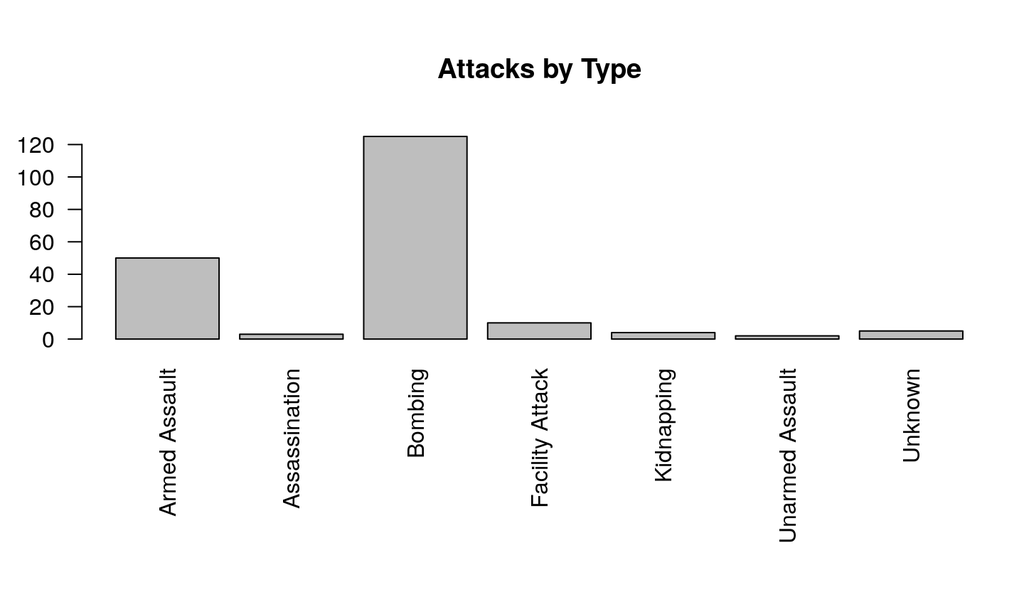

## Session 5: Visualisierung

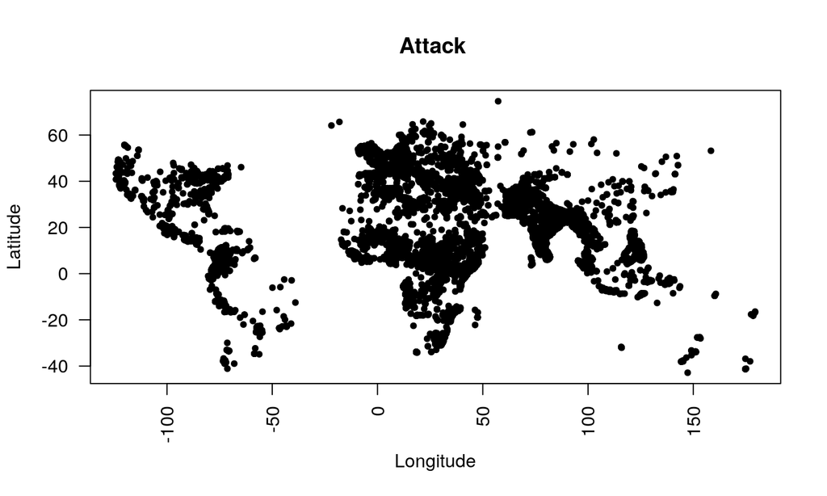

## Session 6: Application Programming Interfaces

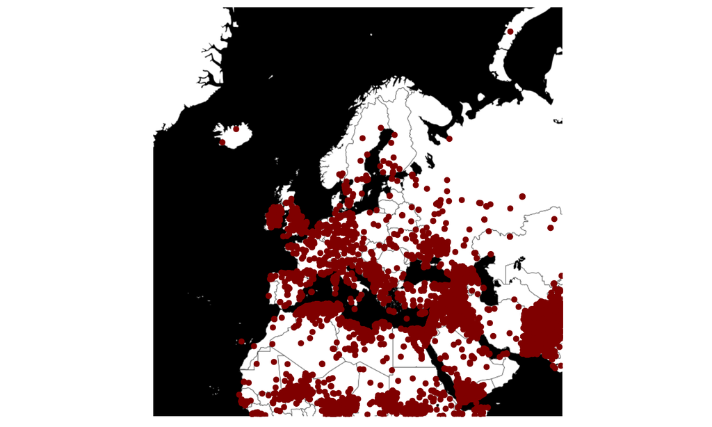

## Session 7: Introduction to Text Mining

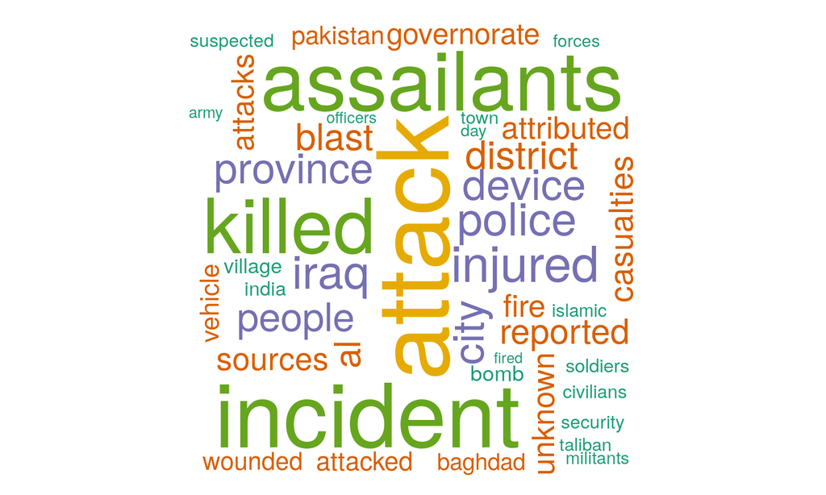

## Session 8: Web Scraping

[figure not shown]

## Agenda

## Agenda

1. Installation von R
2. Installation von RStudio
3. Einrichtung Betriebssystem
4. Installation von Git

   `Pause (5 min)`
5. Klonen des Repositories
6. Was ist R?
7. Was ist RStudio?

   `Pause (5 min)`
8. R Projekte
9. Hilfe
10. Aufgaben

## 1. Installation von R 3.5.0

- Windows: https://cran.r-project.org/bin/windows/base/
- Mac: https://cran.r-project.org/bin/macosx/

## 2. Installation von RStudio

- Alle Plattformen: https://www.rstudio.com/products/rstudio/

## 3. Einrichtung Betriebssystem

- Umgebungsvariable einrichten
- Archiv (ZIP) Dateien (im Notfall 7Zip)
- Dateiendungen anzeigen

## Dateiendungen anzeigen

[figure not shown]

## Dateiendungen anzeigen

[figure not shown]

## 4. Installation von Git

- Git ist ein Versionsverwaltungssystem
- Gemeinsames Bearbeiten und Teilen von Skripten
- Download: https://git-scm.com/downloads

## 5. Klonen des Repositories

- Öffnen der Commandline:
- Windows: Windowstaste + cmd + Enter
- Apple: Terminal ausführen

[figure not shown]

## 5. Klonen des Repositories (2)

```r
# Verzeichnis wechseln Windows
cd C:\\Users\JaneDoe\Uni\R-Workshop
# Verzeichnis wechseln Mac
cd /home/JaneDoe/Uni/R-Workshop

# Repository klonen
git clone https://github.com/jandix/intro-dc-with-r

# in das Repository Verzeichnis wechseln
cd intro-dc-with-r

# Repository aktualisieren (pull)
git pull
```

## 6. Was ist R?

## Über R

- "R ist eine freie Programmiersprache für statistische Berechnungen und Grafiken" (Wikipedia)
- Besondere Datenstrukturen und Funktionen für Statistik \(\rightarrow\) Vorteil und Nachteil zugleich
- Unglaublich erweiterbar und flexibel durch sogenannte R-Pakete \(\rightarrow\) "klassische" Datenanalyse, Text Mining, Webseiten, Presentationen erstellen, Grafiken erstellen, Reports schreiben, Daten runterladen

## Ein kleines Beispiel

```r
# Dies ist ein Kommentar. Diesen muss ich nicht abschreiben.
# Er dient nur dazu, meinen Code zu erklären.
text <- "Hello World"
x <- 1:50
y <- rnorm(50)
plot(x = x, y = y)
```

[output not shown]

## 7. Was ist RStudio?

## Über RStudio

- Integrated Development Environment
- funktioniert nur mit R
- macht uns die "Welt" sehr viel einfacher

## RStudio Tour

- Options
- Global Environment
- Package Manager
- Plots
- Terminal vs Script

## 8. R Projekte

- data/
- plots/
- session1.R
- session2.R …

## 9. Hilfe

- Stack Overflow
- Google
- Help
- ?function
- (Twitter)

## 10. Aufgaben

1. Erstellen Sie ein R-Projekt im vorgestellten Format